# Facebook Live Sellers in Thailand

by Bernardo Augusto

Link of the dataset: https://archive.ics.uci.edu/ml/datasets/Facebook+Live+Sellers+in+Thailand#

## Notebook - Table of Content

1. **Description of the dataset**

   1.1. **Abstract**

   1.2. **Source**

   1.3. **Attribute Information**
1. **Importing necessary Libraries**
1. **Loading Data**
1. **Data Cleaning**
1. **Exploratory Analysis**

   5.1. **Distribution of Posts x Status Type**

   5.2. **Distribution of Posts x Hour**

   5.3. **Distribution of Posts x Day of Month**

   5.5. **Heat Map**

   5.6. **Drop the Correlated Features**

   6.1. **Silhouette Method**

   6.2. **K-Means**

   6.3. **Agglomerative Clustering**

   6.4. **Mini-Batch K-Means**

   6.5. **BIRCH**
1. **Other Algorithms**

   7.1. **Affinity Propagation**

   7.2 **DBSCAN**

   7.3 **Mean Shif**

   7.4 **OPTICS**
1. **Evaluation of the models**

   8.1. **Algorithm Chosen - K-Means**

   8.2. **Distribution of Clusters**

   8.3. **Undersampling**

   8.4. **Cluster Distribution (after undersampling)**)

   8.5. **Cluster Profile Based on Shares And Likes**

   8.6. **Cluster's Profile Based on Type Status And Likes**

   8.7. **Cluster's Profile Based on Likes And Hour**

   8.8. **Cluster's Profile Based on Likes And Month**

   8.9. **Cluster's Profile Based on Interations And Likes**

   8.10. **Cluster's Profile Based on Hour And Interations**
1. **Conclusion**

## 1. Description of the dataset

#### 1.1. Abstract

- **Facebook pages** of **10 Thai fashion and cosmetics retail sellers**
- **Posts** of a **different nature**
  - **video**
  - **photos**
  - **statuses**
  - **links**
- **Engagement metrics** consist of:
  - **comments**
  - **shares**
  - **reactions**

| Data Set Characteristics | Attribute Characteristics | Associated Tasks | Number of Instances | Number of Attributes | Missing Values | Area | Date Donated | Number of Web Hits |
| --- | --- | --- | --- | --- | --- | --- | --- | --- |
| Multivariate | Integer | Clustering | 7051 | 12 | N/A | Business | 2019-04-22 | 54516 |

#### 1.2. Source

- Nassim Dehouche, Mahidol University International College, nassim.deh '@' mahidol.edu

#### 1.3. Data Set Information

- The **variability of consumer engagement** is **analysed** through a **Principal Component Analysis**, highlighting the changes induced by the use of Facebook Live
- The **seasonal component** is **analysed** through a study of the averages of the **different engagement metrics for different time-frames** (hourly, daily and monthly)
- Finally, we **identify statistical outlier posts, that are qualitatively analyzed further, in terms of their selling approach and activities**

#### 1.4. Attribute Information

- **status_id** - unique identifier of the post
- **status_type** - type of the post
- **status_published** - date and time of when the post was post
- **num_reactions** - number of likes, loves, wows, hahas, sads, and angrys
- **num_comments** - number of comments
- **num_shares** - number of shares
- **num_likes** - number of likes
- **num_loves** - number of loves
- **num_wows** - number of wows
- **num_hahas** - number of hahas
- **num_sads** - number of sads
- **num_angrys** - number of angrys

## 2. Importing necessary Libraries

```python
# imports
import pandas as pd
import seaborn as sns
import matplotlib.pyplot as plt
from sklearn.decomposition import PCA
from sklearn.cluster import KMeans
import seaborn as sns
from matplotlib import pyplot as pl
import numpy as np
from sklearn import metrics
from sklearn.cluster import KMeans
from sklearn.cluster import AgglomerativeClustering
from sklearn.cluster import MiniBatchKMeans
from sklearn.cluster import AffinityPropagation
from sklearn.cluster import Birch
from sklearn.cluster import DBSCAN
from sklearn.cluster import MeanShift
from sklearn.cluster import OPTICS
```

## 3. Loading Data

```python
# Control delimiters, rows, column names with read_csv
data = pd.read_csv('/Users/bernardoaugusto/Downloads/Live_20210128.csv')
```

- Check the **shape** of the data loaded

```
(7050, 16)
```

- **First 5 rows** of the Dataframe

|  | status_id | status_type | status_published | num_reactions | num_comments | num_shares | num_likes | num_loves | num_wows | num_hahas | num_sads | num_angrys | Column1 | Column2 | Column3 | Column4 |
| --- | --- | --- | --- | --- | --- | --- | --- | --- | --- | --- | --- | --- | --- | --- | --- | --- |
| 0 | 1 | video | 4/22/2018 6:00 | 529 | 512 | 262 | 432 | 92 | 3 | 1 | 1 | 0 | NaN | NaN | NaN | NaN |
| 1 | 2 | photo | 4/21/2018 22:45 | 150 | 0 | 0 | 150 | 0 | 0 | 0 | 0 | 0 | NaN | NaN | NaN | NaN |
| 2 | 3 | video | 4/21/2018 6:17 | 227 | 236 | 57 | 204 | 21 | 1 | 1 | 0 | 0 | NaN | NaN | NaN | NaN |
| 3 | 4 | photo | 4/21/2018 2:29 | 111 | 0 | 0 | 111 | 0 | 0 | 0 | 0 | 0 | NaN | NaN | NaN | NaN |
| 4 | 5 | photo | 4/18/2018 3:22 | 213 | 0 | 0 | 204 | 9 | 0 | 0 | 0 | 0 | NaN | NaN | NaN | NaN |

## 4. Data Cleaning

- Discover the amount of **data missing**

```
status_id              0
status_type            0
status_published       0
num_reactions          0
num_comments           0
num_shares             0
num_likes              0
num_loves              0
num_wows               0
num_hahas              0
num_sads               0
num_angrys             0
Column1             7050
Column2             7050
Column3             7050
Column4             7050
dtype: int64
```

- Get all the features columns **except the last 4 collumns**

```python
features = list(data.columns)[:-4]

df = data[features]
```

- **Check** if there is any more **missing data**

```
status_id           0
status_type         0
status_published    0
num_reactions       0
num_comments        0
num_shares          0
num_likes           0
num_loves           0
num_wows            0
num_hahas           0
num_sads            0
num_angrys          0
dtype: int64
```

- **Shape** obtained after **dropping last 4 collumns**

```
(7050, 12)
```

- Check the **dataframe informations** like:
  - **Collumn name**
  - **Number of rows**
  - **Data type**

```
<class 'pandas.core.frame.DataFrame'>
RangeIndex: 7050 entries, 0 to 7049
Data columns (total 12 columns):
 #   Column            Non-Null Count  Dtype
---  ------            --------------  -----
 0   status_id         7050 non-null   int64
 1   status_type       7050 non-null   object
 2   status_published  7050 non-null   object
 3   num_reactions     7050 non-null   int64
 4   num_comments      7050 non-null   int64
 5   num_shares        7050 non-null   int64
 6   num_likes         7050 non-null   int64
 7   num_loves         7050 non-null   int64
 8   num_wows          7050 non-null   int64
 9   num_hahas         7050 non-null   int64
 10  num_sads          7050 non-null   int64
 11  num_angrys        7050 non-null   int64
dtypes: int64(10), object(2)
memory usage: 661.1+ KB
```

- Turn the **status_published** feature into **datetime**

```python
df['status_published'] = pd.to_datetime(df['status_published'])
```

- Creation of **4 new features**:
  - **year**
  - **month**
  - **day**
  - **hour**

```python
df['year'] = df['status_published'].dt.year
df['month'] = df['status_published'].dt.month
df['day'] = df['status_published'].dt.day
df['hour'] = df['status_published'].dt.hour
```

- **Drop** the **status_id** collumn since it is **not** gonna be **used** for **analysis or for clustering**

```python
df = df.drop(['status_id'], axis=1)
```

## 5. Exploratory Analysis

#### 5.1. Distribution of Posts x Status Type

- **Photo** posts is the **predominant class** followed by video

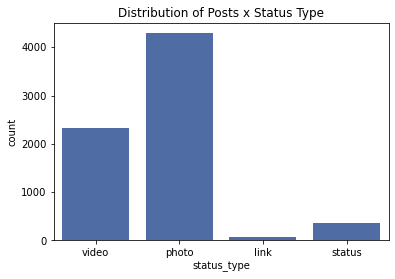

#### 5.2. Distribution of Posts x Hour

- **Posts** **don't** usually are **posted** around **13:00 and 19:00**

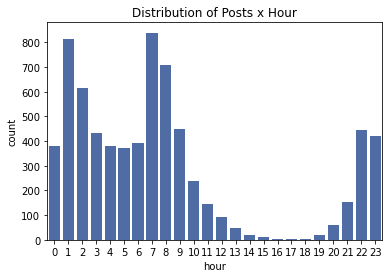

#### 5.3. Distribution of Posts x Day of Month

- **Posts** are **fairly distributed** but in **day 31 of the month have a bit less**
- Maybe because not all month have 31 days

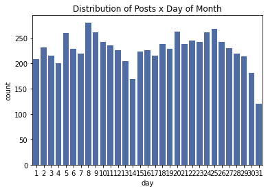

- In the **month 7** usually there is **less posts**
- Besides that posts are fairly distributed

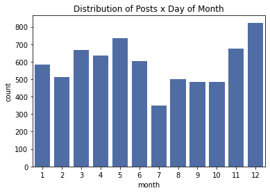

- Years **2017 and 2018** have the **most** amount of **posts**
- Maybe because it was identified that posts can affect sales

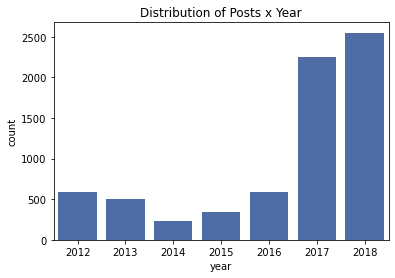

#### 5.5. Heat Map

- **Heat map** allows us to see if there is **correlation** between **features**

[figure not shown]

#### 5.6. Drop the Correlated Features

- **Correlated** features were:
  - **num_reactions**
  - **num_loves**
  - **year**
  - **num_comments**

```python
df = df.drop(['num_reactions', 'num_loves', 'year', 'num_comments'], axis=1)
```

#### 5.7. Heat Map after Dropping the Correlated Features

- Features now are not super correlated

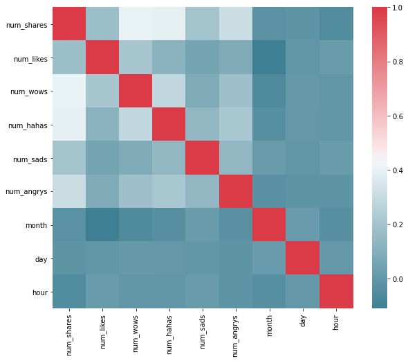

- **Dictionary** with the **key as type of the post** and **value as dummy** so the values can be used in the clusters algorithms.

```python
s_type = {'video': 1,'photo': 2, 'status': 3,'link': 4}
```

- **Transform** the **post type** into **numbers** so we can analyse them via cluster

```python
df.status_type = [s_type[item] for item in df.status_type]
```

- **Drop** the **status_published**

```python
df = df.drop('status_published', axis=1)
```

## 6. Best Algorithms

#### 6.1. Silhouette Method

- This **method allow** us to decide what the **best number of clusters are**
- **2 cluster** is the number of cluster with the **highest score (85%)**
- For that reason it is the decided number of clusters

```python
# choosing the best number of clusters using the silhouette score
range_n_clusters = list(range(2,10))

for n_clusters in range_n_clusters:
    clusterer = KMeans(n_clusters=n_clusters)
    preds = clusterer.fit_predict(df)
    centers = clusterer.cluster_centers_

    score = metrics.silhouette_score(df, preds)
    print("For n_clusters = {}, silhouette score is {})".format(n_clusters, score))
```

```
For n_clusters = 2, silhouette score is 0.8534671889199728)
For n_clusters = 3, silhouette score is 0.8056051502662949)
For n_clusters = 4, silhouette score is 0.6284172846007556)
For n_clusters = 5, silhouette score is 0.6297657710495062)
For n_clusters = 6, silhouette score is 0.6310532605310075)
For n_clusters = 7, silhouette score is 0.677439387139777)
For n_clusters = 8, silhouette score is 0.6472581026856694)
For n_clusters = 9, silhouette score is 0.6358861373680589)
```

#### 6.2. K-Means

- In this algorithm the **Clusters are very well delimited**
- For this reason it is a **good algorithm**

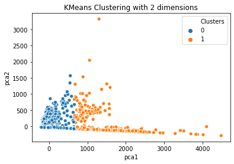

#### 6.3. Agglomerative Clustering

- This algorithm like the above, also have the **Clusters well delimited**
- For this reason it is a **good algorithm**

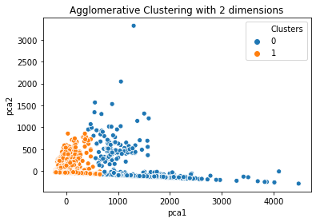

#### 6.4. Mini-Batch K-Means

- This algorithm also have the **Clusters well delimited**
- For this reason it is a **good algorithm**

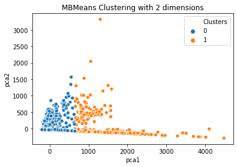

#### 6.5. BIRCH

- The algorithm identified **3 clusters**
- And these are **well delimited**
- can be considered **one of the best**

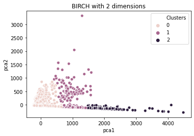

## 7. Other Algorithms

These algorithms dont perform as well as the shown previously

#### 7.1. Affinity Propagation

- This **algorithm doesn't** have the **cluster well delimited**
- So we can conclude that **is not good for this problem**

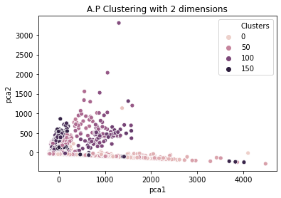

#### 7.2. DBSCAN

- The algorithm identified **2 clusters**
- But these **can't distinguished**
- For this reason is **not a good algorithm for the problem**

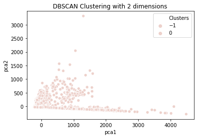

#### 7.3. Mean Shif

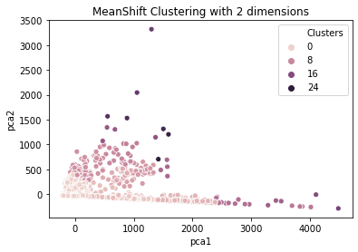

#### 7.4. OPTICS

- The algorithm **doesn't** have the **cluster well delimited**
- For that reason we can conclude that **is not good for this problem**

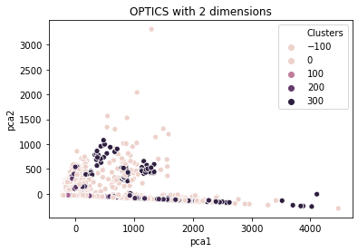

## 8. Evaluation of the models

- Since this is an **unsupervised clustering**. We do **not have** a **tagged feature** to **evaluate the score of our model**
- The **purpose** of this section is to **study the patterns** in the clusters formed and *+determine the nature** of the clusters' patterns.
- For that, we will be having a **look at the data in light of clusters via exploratory data analysis and drawing conclusions**

#### 8.1. Algorithm Chosen - K Means

- After some thought, it was decided that **K Means should be used**
- Because it only contains **2 clusters** so it's **easiers to interpreter the results**

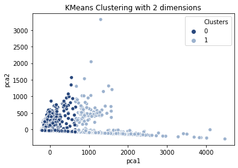

#### 8.2. Distribution of Clusters

- Can be observed that the **clusters aren't fairly distributed**

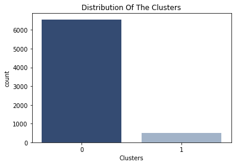

- **Number of rows in each cluster**

```
0    6562
1     488
Name: Clusters, dtype: int64
```

- There is **two techniques** that are usefull to **fix** distribution of **unbalanced classes**:
  - **Oversampling**
  - **Undersampling**

#### 8.3. Undersampling

- **Function for undersampling**

```python
def downsample(df, label_col_name):
    # find the number of observations in the smallest group
    nmin = df[label_col_name].value_counts().min()
    return (df
            # split the dataframe per group
            .groupby(label_col_name)
            # sample nmin observations from each group
            .apply(lambda x: x.sample(nmin))
            # recombine the dataframes
            .reset_index(drop=True)
            )
```

- It was created a **new dataframe after aplying the undersampling**

```python
df_us = downsample(df, 'Clusters')
```

- **After** the use of this **technique** the **clusters** are **fairly distributed**

```
1    0.5
0    0.5
Name: Clusters, dtype: float64
```

#### 8.4. Cluster Distribution (after undersampling)

- Now are **fairly distributed**

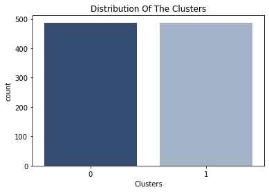

#### 8.5. Cluster's Profile Based on Shares And Likes

- We can see that the **sellers of the cluster 0 have less shares and less likes than the sellers of the cluster 1**

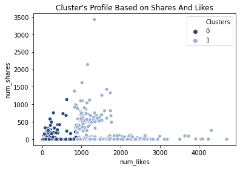

#### 8.6. Cluster's Profile Based on Type Status And Likes

- We can see that the **sellers of the cluster 0 independetly of the status type, always have less likes than the sellers of cluster 1**

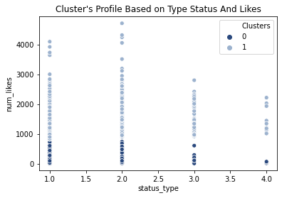

#### 8.7. Cluster's Profile Based on Likes And Hour

- We can see that the **sellers of the cluster 0 independetly of the hour, always have less likes than the sellers of cluster 1 during 15:00 - 20:00**

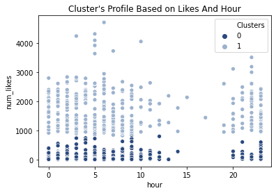

#### 8.8. Cluster's Profile Based on Likes And Month

- Once again, **sellers of the cluster 0 independetly of the month, always have less likes than the sellers of cluster 1**

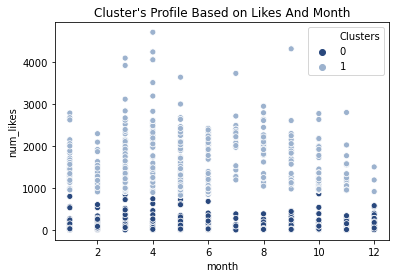

#### 8.9. Cluster's Profile Based on Interations And Likes

- We can see that the, **independently of the number of likes, when we have around 1000 likes is when we have the most amount of wows**
- There is **no much difference between the two clusters in this analysis, the number of hahas usually never passes the 30's**
- There is **no much of difference again, the number of sads is usually between 0 - 5**
- The **number of angrys never flutuate that much, is usually aroud 0 - 5**

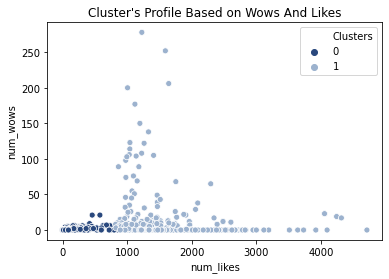

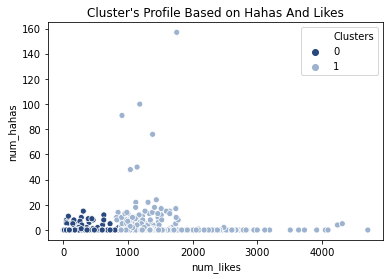

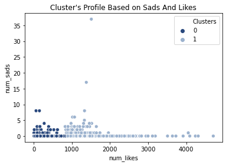

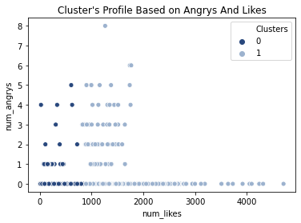

#### 8.10. Cluster's Profile Based on Hour And Interations

- We can see that we always have **more interactions between 5:00 - 10:00**

[figure not shown]

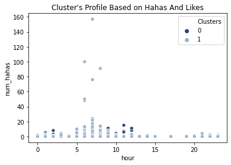

[figure not shown]

[figure not shown]

## 9. Conclusion

- Can be concluded that the **cluster 0 has seller that are in general less popular**. In the other hand, the **sellers of the cluster 1 have sellers that are super popular**
- As we saw in the graph "Cluster's Profile Based on Shares And Likes", the **sellers from cluster 0 have less shares and less likes than the sellers of the cluster 1**
- In the following graph "Cluster's Profile Based on Type Status And Likes", the **sellers of the cluster 0 independetly of the status type, always have less likes than the sellers of cluster 1**
- In the graph "Cluster's Profile Based on Likes And Hour" we could concluded that once again the **sellers from cluster 1 have more likes than the sellers from cluster 0 independently of the hour of the day**
- But we can also conclude that during **15:00 - 20:00**, **isn't a good time to post because there is not much likes at this time of the day**
- Based on the graph "Cluster's Profile Based on Likes And Month" we could conclude that **there is not a month that have a lot more likes than the other and once again the sellers in the cluster 1, have more likes than the seller of cluster 0**
- In terms of number of interactions with the posts (wows, hahas, sads and angrys), the **number of likes doesn't influenciate that much**
- In terms of the hour of the post, can clearly be seen that between **5:00 - 10:00 there is more interactions than any other time of the day**